# RMarkdown Class Schedule

Daniel Chadourne

September 17, 2020

# Class Schedule

### STAT 184: Introduction to R Programmaing

R is a powerful, open-source programming language used widely for applications in statistics and data science. Students will be expected to access, join, wrangle, clean, and visualize real data. The course will emphasize use of “tidyverse” R packages (e.g. dplyr, ggplot2), although students will also be exposed to Base R and other packages. The course focuses on descriptive and graphical summary techniques rather than inferential statistical techniques. You can find more details in this [link](https://bulletins.psu.edu/university-course-descriptions/undergraduate/stat/).

[figure not shown]

### SRA 211: Threat of Terrorism and Crime

SRA is and in-depth look at terrorism, how to define it, and how we as analysts can understand and make sense of it. During the class we will conduct case analyses and analyses of recent news articles in the context of in-class discussions. We will also be exposed to diagnostic and contrarian techniques to be used in our assignments [link](https://learning.ist.psu.edu/ist-sra-courses/sra-211/)

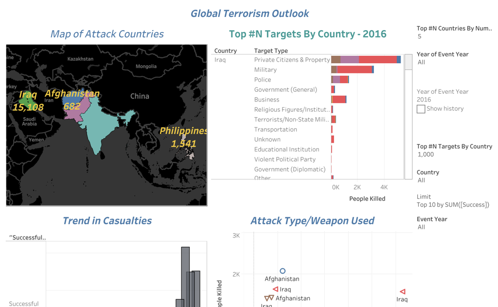

### SODA 308: Research Design Social Data Analytics

SODA 308, primarily for SODA majors, focuses on how to conduct research using social media data and other “Big” data datasets. The course will also confront how bias and other perception can effect our analyses. The course will also discuss exploratory technicque to be used in our furture research.

[link](https://bulletins.psu.edu/university-course-descriptions/undergraduate/soda/)

[figure not shown]